# EDA_Olympiad_Canisius_2025

CipherSci

2025-04-26

# Introduction

This project focuses on cleaning and analyzing the electricity consumption data provided by the Building Data Genome Project 2.  
Our objective is to preprocess the raw datasets, handle missing values, detect anomalies, and explore patterns related to building energy usage.

# Data Cleaning Summary

The electricity dataset required significant preprocessing to ensure its integrity for analysis. Initial inspection revealed timestamp inconsistencies, missing readings, and a large number of zero and near-zero values likely resulting from sensor errors. To address these issues, timestamps were corrected by inferring missing values based on surrounding data points. Zero and near-zero meter readings were replaced with NA to avoid biasing energy consumption trends. Buildings associated with the Swan site, which exhibited over 50% missing data, were removed to maintain dataset quality. Finally, rows with excessive missingness were filtered out to prepare a clean and robust dataset for downstream analysis.

# Exploratory Data Analysis (EDA) Summary

The cleaned dataset was explored to uncover usage patterns and insights. Missing data patterns were visualized, revealing that missingness was sporadic across buildings and timestamps, likely due to intermittent sensor failures rather than systematic issues. Analysis of average energy usage identified that health and educational buildings consumed the most electricity on average. Hourly trends showed distinct daily cycles, with energy usage peaking during business hours and declining overnight. Further analysis revealed a positive correlation between outdoor air temperature and electricity consumption, suggesting increased cooling demands during warmer periods. These insights provide a foundational understanding of building energy behavior and external influences on consumption.

# Libraries and Data Loading

```r
rm(list = ls())

library(tidyverse)
library(lubridate)
library(naniar)
```

```r
library(dplyr)
library(ggplot2)

setwd(dirname(rstudioapi::getActiveDocumentContext()$path))

electricity <- read_csv("data/electricity.csv")
metadata <- read_csv("data/metadata.csv")
weather <- read_csv("data/weather.csv")
```

# Initial Data Inspection

We first explore the dimensions of the datasets and identify potential issues such as missing timestamps or invalid zero values.

```r
dim(electricity)
```

```
## [1] 17544  1579
```

```r
colnames(electricity)[1:10]
```

```
##  [1] "timestamp"                 "Panther_parking_Lorriane"
##  [3] "Panther_lodging_Cora"      "Panther_office_Hannah"
##  [5] "Panther_lodging_Hattie"    "Panther_education_Teofila"
##  [7] "Panther_education_Jerome"  "Panther_retail_Felix"
##  [9] "Panther_parking_Asia"      "Panther_education_Misty"
```

```r
colSums(is.na(electricity[, 1:10]))
```

```
##                 timestamp  Panther_parking_Lorriane      Panther_lodging_Cora
##                         0                        11                        11
##     Panther_office_Hannah    Panther_lodging_Hattie Panther_education_Teofila
##                        12                        12                        11
##  Panther_education_Jerome      Panther_retail_Felix      Panther_parking_Asia
##                        10                        11                        11
##   Panther_education_Misty
##                        20
```

We also review the first few timestamps:

```r
head(electricity$timestamp, 20)
```

```
##  [1] "2016-01-01 00:00:00 UTC" "2016-01-01 01:00:00 UTC"
##  [3] "2016-01-01 02:00:00 UTC" "2016-01-01 03:00:00 UTC"
##  [5] "2016-01-01 04:00:00 UTC" "2016-01-01 05:00:00 UTC"
##  [7] "2016-01-01 06:00:00 UTC" "2016-01-01 07:00:00 UTC"
##  [9] "2016-01-01 08:00:00 UTC" "2016-01-01 09:00:00 UTC"
## [11] "2016-01-01 10:00:00 UTC" "2016-01-01 11:00:00 UTC"
## [13] "2016-01-01 12:00:00 UTC" "2016-01-01 13:00:00 UTC"
## [15] "2016-01-01 14:00:00 UTC" "2016-01-01 15:00:00 UTC"
## [17] "2016-01-01 16:00:00 UTC" "2016-01-01 17:00:00 UTC"
## [19] "2016-01-01 18:00:00 UTC" "2016-01-01 19:00:00 UTC"
```

# Data Cleaning Steps

## Timestamp Correction

While converting timestamps, it was found that 731 rows had NA timestamps, mostly related to missing 24-hour records. These were imputed by inferring from neighboring timestamps.

```r
bad_timestamps <- electricity$timestamp[is.na(ymd_hms(electricity$timestamp))]
length(bad_timestamps)
```

```
## [1] 731
```

```r
unique(bad_timestamps)
```

```
##   [1] "2016-01-01 UTC" "2016-01-02 UTC" "2016-01-03 UTC" "2016-01-04 UTC"
##   [5] "2016-01-05 UTC" "2016-01-06 UTC" "2016-01-07 UTC" "2016-01-08 UTC"
##   [9] "2016-01-09 UTC" "2016-01-10 UTC" "2016-01-11 UTC" "2016-01-12 UTC"
##  [13] "2016-01-13 UTC" "2016-01-14 UTC" "2016-01-15 UTC" "2016-01-16 UTC"
##  [17] "2016-01-17 UTC" "2016-01-18 UTC" "2016-01-19 UTC" "2016-01-20 UTC"
##  [21] "2016-01-21 UTC" "2016-01-22 UTC" "2016-01-23 UTC" "2016-01-24 UTC"
##  [25] "2016-01-25 UTC" "2016-01-26 UTC" "2016-01-27 UTC" "2016-01-28 UTC"
##  [29] "2016-01-29 UTC" "2016-01-30 UTC" "2016-01-31 UTC" "2016-02-01 UTC"
##  [33] "2016-02-02 UTC" "2016-02-03 UTC" "2016-02-04 UTC" "2016-02-05 UTC"
##  [37] "2016-02-06 UTC" "2016-02-07 UTC" "2016-02-08 UTC" "2016-02-09 UTC"
##  [41] "2016-02-10 UTC" "2016-02-11 UTC" "2016-02-12 UTC" "2016-02-13 UTC"
##  [45] "2016-02-14 UTC" "2016-02-15 UTC" "2016-02-16 UTC" "2016-02-17 UTC"
##  [49] "2016-02-18 UTC" "2016-02-19 UTC" "2016-02-20 UTC" "2016-02-21 UTC"
##  [53] "2016-02-22 UTC" "2016-02-23 UTC" "2016-02-24 UTC" "2016-02-25 UTC"
##  [57] "2016-02-26 UTC" "2016-02-27 UTC" "2016-02-28 UTC" "2016-02-29 UTC"
```

[output cut: 168 more lines]

```r
electricity <- electricity %>%
  mutate(timestamp = ymd_hms(timestamp))
na_time_rows <- which(is.na(electricity$timestamp))
electricity_fixed <- electricity

for (i in na_time_rows) {
  if (i > 1 && !is.na(electricity_fixed$timestamp[i - 1])) {
    electricity_fixed$timestamp[i] <- electricity_fixed$timestamp[i - 1] + hours(1)
  } else if (i < nrow(electricity_fixed) && !is.na(electricity_fixed$timestamp[i + 1])) {
    electricity_fixed$timestamp[i] <- electricity_fixed$timestamp[i + 1] - hours(1)
  } else {
    electricity_fixed$timestamp[i] <- NA
  }
}

sum(is.na(electricity_fixed$timestamp))
```

```
## [1] 0
```

# Zero Value Replacement

Zero meter readings, considered implausible, were replaced with NA to avoid biasing the analysis.

```r
electricity_cleaned <- electricity_fixed
electricity_cleaned[, -1] <- electricity_cleaned[, -1] %>%
  mutate(across(everything(), ~ ifelse(.x == 0, NA, .x)))
```

# Sampling for Missing Data Visualization

To visualize missing patterns without overwhelming memory, 30 buildings and 2500 timestamps were randomly sampled.

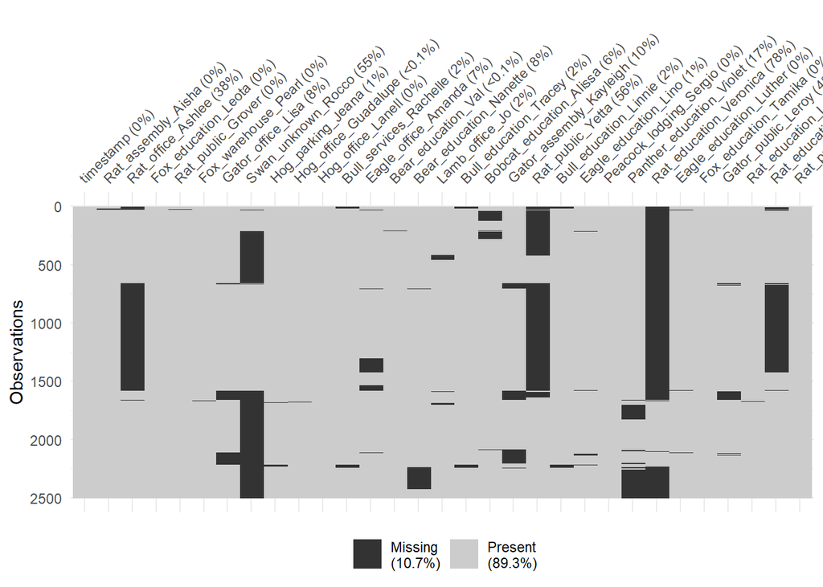

```r
set.seed(123)

few_buildings <- sample(colnames(electricity_cleaned)[-1], 30)
electricity_small <- electricity_cleaned %>%
  select(timestamp, all_of(few_buildings)) %>%
  slice_sample(n = 2500)

vis_miss(electricity_small, cluster = TRUE)
```

The missingness heatmap reveals that approximately 11% of the sampled electricity meter readings are missing. Missing values appear scattered across different timestamps and building sites, with no single dominant pattern. This suggests that data loss is likely due to sensor outages or communication errors rather than systematic gaps.

# Missing Values Analysis

We explored missing values across sites and building types.

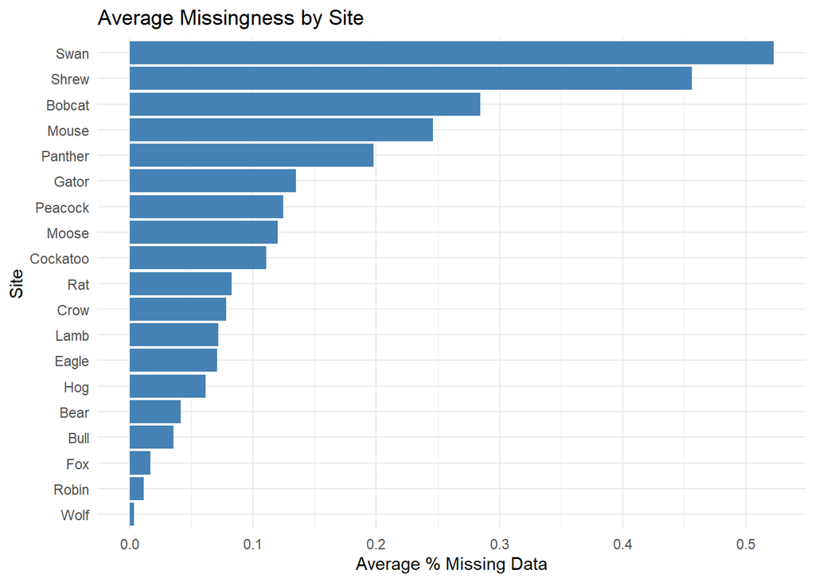

```r
# Build building info
building_info <- tibble(building = colnames(electricity_cleaned)[-1]) %>%
  separate(building, into = c("site", "type", "tag"), sep = "_", remove = FALSE)

missing_perc_building <- colMeans(is.na(electricity_cleaned[, -1]))
missing_perc_building <- tibble(building = names(missing_perc_building),
                                missing_perc = missing_perc_building)

building_missing_summary <- building_info %>%
  left_join(missing_perc_building, by = "building")

missing_by_site <- building_missing_summary %>%
  group_by(site) %>%
  summarise(avg_missing_perc = mean(missing_perc, na.rm = TRUE)) %>%
  arrange(desc(avg_missing_perc))

missing_by_type <- building_missing_summary %>%
  group_by(type) %>%
  summarise(avg_missing_perc = mean(missing_perc, na.rm = TRUE)) %>%
  arrange(desc(avg_missing_perc))

# Plot Missingness by Site
ggplot(missing_by_site, aes(x = reorder(site, avg_missing_perc), y = avg_missing_perc)) +
  geom_col(fill = "steelblue") +
  coord_flip() +
  labs(title = "Average Missingness by Site",
       x = "Site",
       y = "Average % Missing Data") +
  theme_minimal()
```

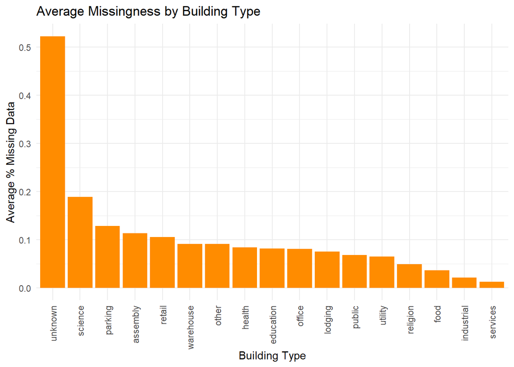

```r
# Plot Missingness by Building Type
ggplot(missing_by_type, aes(x = reorder(type, -avg_missing_perc), y = avg_missing_perc)) +
  geom_col(fill = "darkorange") +
  labs(title = "Average Missingness by Building Type",
       x = "Building Type",
       y = "Average % Missing Data") +
  theme_minimal() +
  theme(axis.text.x = element_text(angle = 90, vjust = 0.5, hjust = 1))
```

# Dropping Swan Columns

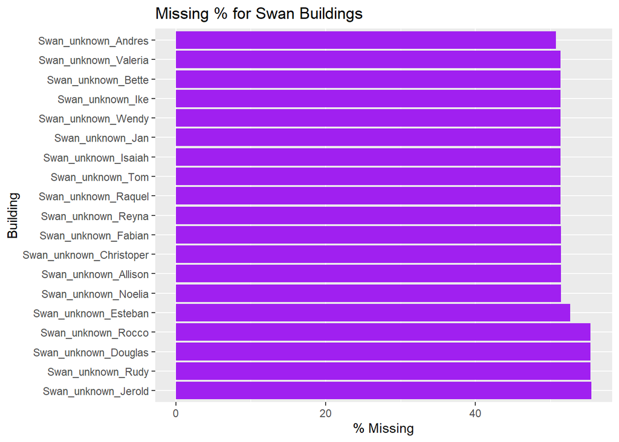

```r
swan_columns <- electricity_cleaned %>%
  select(starts_with("Swan"))

total_na_swan <- sum(is.na(swan_columns))
percent_na_swan <- colMeans(is.na(swan_columns)) * 100

# Plot Missingness in Swan

tibble(building = names(percent_na_swan), missing_perc = percent_na_swan) %>%
  ggplot(aes(x = reorder(building, -missing_perc), y = missing_perc)) +
  geom_col(fill = "purple") +
  coord_flip() +
  labs(title = "Missing % for Swan Buildings", x = "Building", y = "% Missing")
```

```r
# Remove Swan buildings
electricity_cleaned <- electricity_cleaned %>%
  select(-starts_with("Swan"))
```

Buildings associated with the “Swan” site displayed over 50% missing readings. To maintain data quality and avoid introducing noise, these buildings were systematically removed from the dataset. This decision preserves the integrity of the final cleaned dataset.

# Near-Zero Value Handling

Near-zero meter readings (<0.01) were replaced with NA as they indicate faulty measurements.

```r
small_value_threshold <- 0.01
electricity_cleaned[, -1] <- electricity_cleaned[, -1] %>%
  mutate(across(everything(), ~ ifelse(!is.na(.x) & .x < small_value_threshold, NA, .x)))
```

Near-zero readings (less than 0.01 kWh) were assumed to indicate faulty sensors or low-activity periods unlikely to represent real consumption. Replacing these values with NA prevents misleading low-consumption trends in downstream modeling.

# Energy Usage by Building and Type

## Top 20 Buildings with Highest Consumption

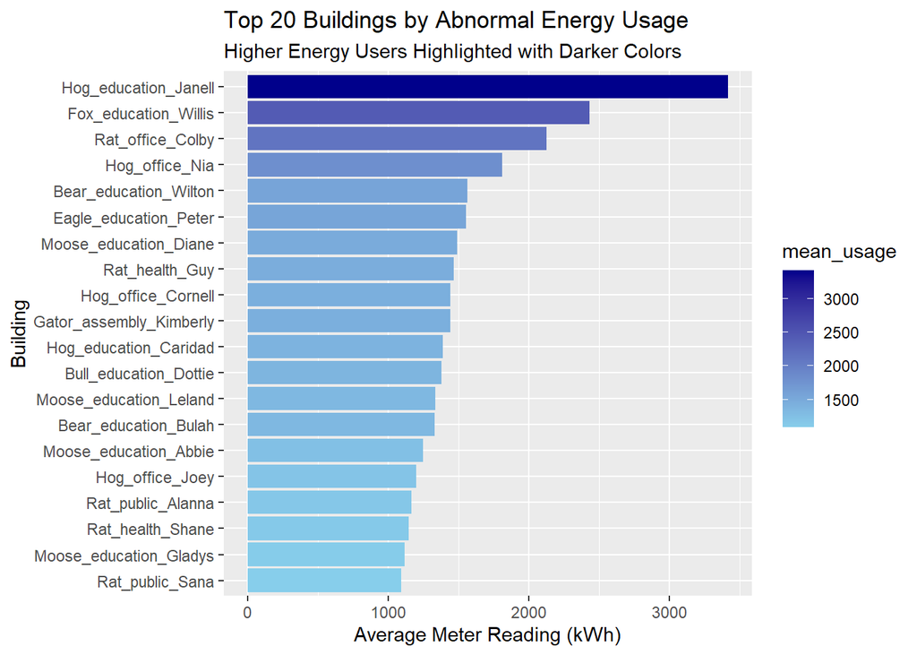

```r
building_means <- colMeans(electricity_cleaned[, -1], na.rm = TRUE)
building_summary <- tibble(building = names(building_means), mean_usage = building_means)

top20_buildings <- building_summary %>%
  arrange(desc(mean_usage)) %>%
  slice_head(n = 20)

ggplot(top20_buildings, aes(x = reorder(building, mean_usage), y = mean_usage, fill = mean_usage)) +
  geom_col() +
  coord_flip() +
  scale_fill_gradient(low = "skyblue", high = "darkblue") +
  labs(title = "Top 20 Buildings by Abnormal Energy Usage",
       subtitle = "Higher Energy Users Highlighted with Darker Colors",
       x = "Building",
       y = "Average Meter Reading (kWh)")
```

The top 20 highest-consuming buildings were identified based on their average electricity usage. These buildings exhibit significantly higher energy demands, likely reflecting operational factors such as building size, hours of operation, or equipment load.

## Energy Usage by Building Type

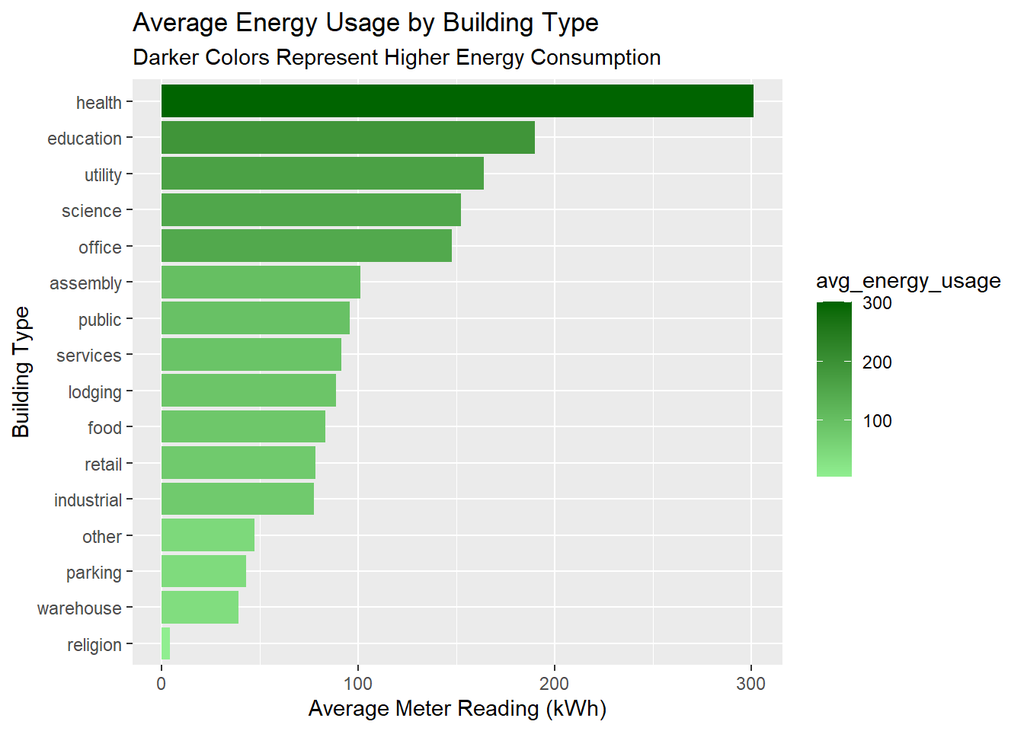

```r
building_summary_full <- building_info %>%
  left_join(building_summary, by = "building")

type_summary <- building_summary_full %>%
  group_by(type) %>%
  summarise(avg_energy_usage = mean(mean_usage, na.rm = TRUE)) %>%
  arrange(desc(avg_energy_usage)) %>%
  filter(type != "unknown")

ggplot(type_summary, aes(x = reorder(type, avg_energy_usage), y = avg_energy_usage, fill = avg_energy_usage)) +
  geom_col() +
  coord_flip() +
  scale_fill_gradient(low = "lightgreen", high = "darkgreen") +
  labs(title = "Average Energy Usage by Building Type",
       subtitle = "Darker Colors Represent Higher Energy Consumption",
       x = "Building Type",
       y = "Average Meter Reading (kWh)")
```

# Time Series Analysis: Hourly Trends

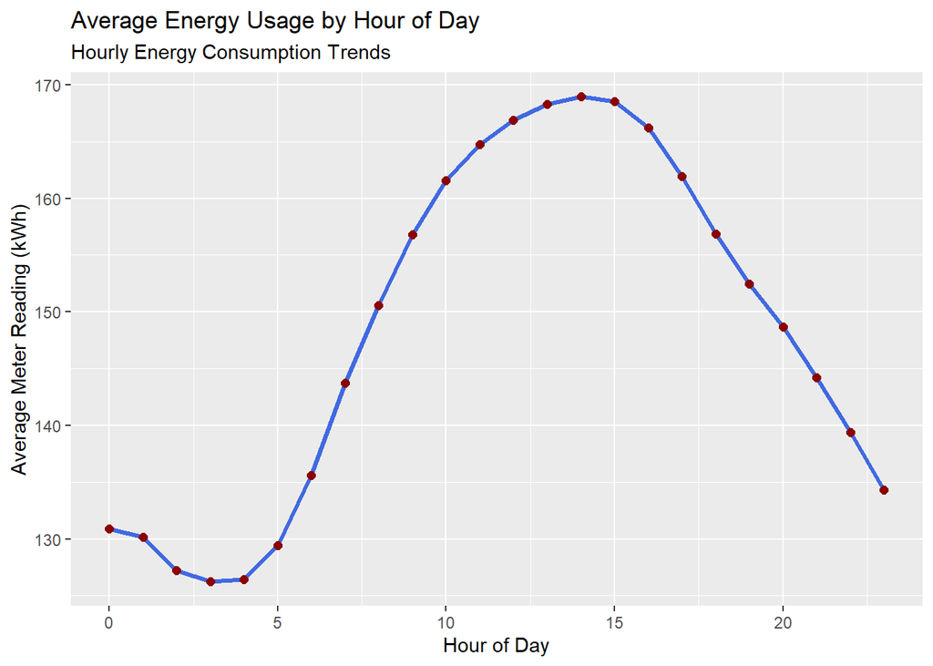

```r
electricity_time_avg <- electricity_cleaned %>%
  mutate(avg_usage = rowMeans(select(., -timestamp), na.rm = TRUE)) %>%
  select(timestamp, avg_usage) %>%
  mutate(hour = hour(timestamp),
         weekday = wday(timestamp, label = TRUE),
         is_weekend = if_else(weekday %in% c("Sat", "Sun"), TRUE, FALSE))

usage_by_hour <- electricity_time_avg %>%
  group_by(hour) %>%
  summarise(avg_hourly_usage = mean(avg_usage, na.rm = TRUE))

ggplot(usage_by_hour, aes(x = hour, y = avg_hourly_usage)) +
  geom_line(color = "royalblue", size = 1.2) +
  geom_point(color = "darkred", size = 2) +
  labs(title = "Average Energy Usage by Hour of Day",
       subtitle = "Hourly Energy Consumption Trends",
       x = "Hour of Day",
       y = "Average Meter Reading (kWh)")
```

Energy usage peaks during regular working hours (approximately 8 AM to 6 PM), and declines overnight. This pattern suggests strong diurnal behavior across the dataset, reinforcing the presence of human-driven energy cycles. Persistent energy consumption during nighttime could indicate baseline loads from critical infrastructure.

# External Factors: Impact of Temperature

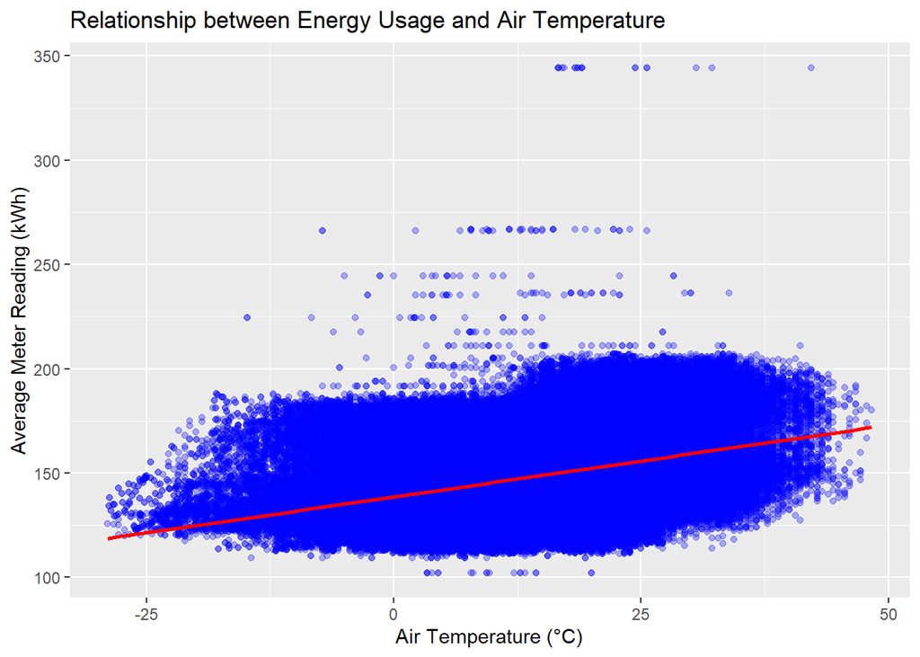

```r
electricity_weather <- electricity_time_avg %>%
  left_join(weather, by = "timestamp") %>%
  filter(!is.na(airTemperature), !is.na(avg_usage))

ggplot(electricity_weather, aes(x = airTemperature, y = avg_usage)) +
  geom_point(alpha = 0.3, color = "blue") +
  geom_smooth(method = "lm", se = FALSE, color = "red") +
  labs(title = "Relationship between Energy Usage and Air Temperature",
       x = "Air Temperature (°C)",
       y = "Average Meter Reading (kWh)")
```

A positive relationship was observed between air temperature and energy usage, suggesting higher electricity consumption during warmer periods. This trend likely reflects increased cooling demands (e.g., air conditioning usage), validating external weather as an important predictive feature.

# Final Dataset Export

```r
threshold <- ncol(electricity_cleaned) * 0.9
electricity_final <- electricity_cleaned %>%
  filter(rowSums(is.na(.)) < threshold)

write_csv(electricity_final, "data/electricity_final_clean_V2.csv")
```

# Conclusion